# Homework 5

STAT 757 – Section 1001  
Instructor: Colin Grudzien

## Due: 10/10/2019

## Instructions

> You may work with others on these problems but you must turn in your own work.  
> You may type your solutions in any way you like (LaTeX, Markdown, Office, etc…) as long as you present your work clearly and in an organized way.  
> **Whenever plotting:**
> - Include a copy of a short R script corresponding to your plot.
> - Your plot must be clearly labeled in all axes, legends, and the plot must include a clear title.
> - The plot must be sensible and easy to read.

## Problems

### Load the library “Faraway” in the R environment. Then proceed to analyze the following data sets in this library:

### Problem 1:

For the `prostate` data, fit a model with `lpsa` as the response and the other variables as predictors.

1. Suppose a new patient with the following values arrives:

```
lcavol lweight age lbph svi lcp
1.44692 3.62301 65.00000 0.30010 0.00000 -0.79851
gleason pgg45
7.00000 15.00000
```

Predict the `lpsa` for this patient along with an appropriate 95% confidence interval (CI).

2. Repeat the last question for a patient with the same values except that he is `age` 20. Explain why the CI is wider.
3. For the model of the previous question, remove all the predictors that are not significant at the 5% level. Now recompute the predictions of the previous question. Are the CIs wider or narrower? Which predictions would you prefer? Explain.

#### Solutions:

##### Problem 1.1

We begin by creating the model and outputting a summary.

```r
library(faraway)
lm_prostate <- lm(lpsa ~ lcavol + lweight + age + lbph + svi + lcp + gleason + pgg45, data=prostate)
summary(lm_prostate)
```

```
##
## Call:
## lm(formula = lpsa ~ lcavol + lweight + age + lbph + svi + lcp +
##     gleason + pgg45, data = prostate)
##
## Residuals:
##     Min      1Q  Median      3Q     Max
## -1.7331 -0.3713 -0.0170  0.4141  1.6381
##
## Coefficients:
##              Estimate Std. Error t value Pr(>|t|)
## (Intercept)  0.669337   1.296387   0.516  0.60693
## lcavol       0.587022   0.087920   6.677 2.11e-09 ***
## lweight      0.454467   0.170012   2.673  0.00896 **
## age         -0.019637   0.011173  -1.758  0.08229 .
## lbph         0.107054   0.058449   1.832  0.07040 .
## svi          0.766157   0.244309   3.136  0.00233 **
## lcp         -0.105474   0.091013  -1.159  0.24964
## gleason      0.045142   0.157465   0.287  0.77503
## pgg45        0.004525   0.004421   1.024  0.30886
## ---
## Signif. codes:  0 '***' 0.001 '**' 0.01 '*' 0.05 '.' 0.1 ' ' 1
##
## Residual standard error: 0.7084 on 88 degrees of freedom
## Multiple R-squared:  0.6548, Adjusted R-squared:  0.6234
## F-statistic: 20.86 on 8 and 88 DF,  p-value: < 2.2e-16
```

Here we suppose that we need to predict a **future observation** for a future patient. In particular, we want to create the dataframe for the hypothetical patient as follows:

```r
new_obs <- c(1.44692, 3.62301, 65.00000, 0.30010, 0.00000, -0.79851, 7.00000, 15.00000)
new_obs <- t(data.frame(new_obs))
colnames(new_obs) <- c('lcavol', 'lweight','age', 'lbph', 'svi', 'lcp', 'gleason', 'pgg45')
```

Now, we construct a **$95\%$ prediction** interval for the new patient given their characteristics,

```r
predict(lm_prostate, new=data.frame(new_obs), interval="prediction")
```

```
##              fit       lwr      upr
## new_obs 2.389053 0.9646584 3.813447
```

##### Problem 1.2

Modifying the patient data so that all other variables are held constant, but the age is given as 20 years,

```r
new_obs_alt <- new_obs
new_obs_alt[3] <- 20
```

we repeat the prediction interval for the individual with equal characteristics except for age,

```r
predict(lm_prostate, new=data.frame(new_obs_alt), interval="prediction")
```

```
##              fit      lwr      upr
## new_obs 3.272726 1.538744 5.006707
```

We note that the prediction interval is substantially wider. The histogram of the ages of the participants in our existing data is pictured as

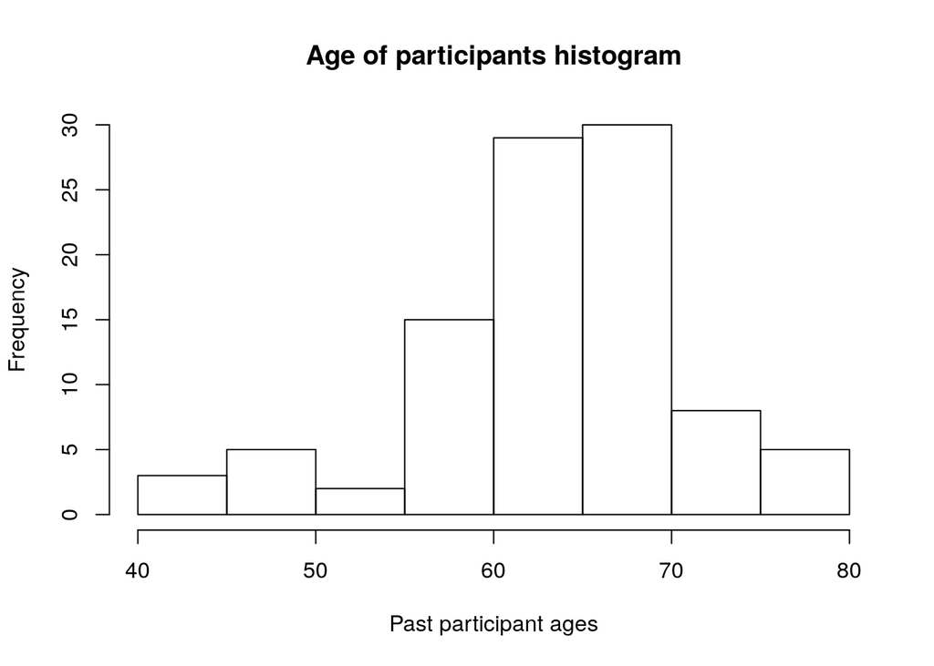

```r
hist(prostate$age, xlab = "Past participant ages", main="Age of participants histogram")
```

such that the age 20 is entirely out of our previous experience. In this case, the uncertainty grows substantially due to the high level of extrapolation in this prediction.

##### Problem 1.3

We consider the predictors in the model that have $5\%$ significance,

```r
summary(lm_prostate)
```

```
##
## Call:
## lm(formula = lpsa ~ lcavol + lweight + age + lbph + svi + lcp +
##     gleason + pgg45, data = prostate)
##
## Residuals:
##     Min      1Q  Median      3Q     Max
## -1.7331 -0.3713 -0.0170  0.4141  1.6381
##
## Coefficients:
##              Estimate Std. Error t value Pr(>|t|)
## (Intercept)  0.669337   1.296387   0.516  0.60693
## lcavol       0.587022   0.087920   6.677 2.11e-09 ***
## lweight      0.454467   0.170012   2.673  0.00896 **
## age         -0.019637   0.011173  -1.758  0.08229 .
## lbph         0.107054   0.058449   1.832  0.07040 .
## svi          0.766157   0.244309   3.136  0.00233 **
## lcp         -0.105474   0.091013  -1.159  0.24964
## gleason      0.045142   0.157465   0.287  0.77503
## pgg45        0.004525   0.004421   1.024  0.30886
## ---
## Signif. codes:  0 '***' 0.001 '**' 0.01 '*' 0.05 '.' 0.1 ' ' 1
##
## Residual standard error: 0.7084 on 88 degrees of freedom
## Multiple R-squared:  0.6548, Adjusted R-squared:  0.6234
## F-statistic: 20.86 on 8 and 88 DF,  p-value: < 2.2e-16
```

We find that lcavol, lweight and svi each are significant at $5\%$. In particular, we fit an alternative model with only these as explanatory variable,

```r
lm_prostate_alt <- lm(lpsa ~ lcavol + lweight + svi, data=prostate)
summary(lm_prostate_alt)
```

```
##
## Call:
## lm(formula = lpsa ~ lcavol + lweight + svi, data = prostate)
##
## Residuals:
##      Min       1Q   Median       3Q      Max
## -1.72964 -0.45764  0.02812  0.46403  1.57013
##
## Coefficients:
##             Estimate Std. Error t value Pr(>|t|)
## (Intercept) -0.26809    0.54350  -0.493  0.62298
## lcavol       0.55164    0.07467   7.388  6.3e-11 ***
## lweight      0.50854    0.15017   3.386  0.00104 **
## svi          0.66616    0.20978   3.176  0.00203 **
## ---
## Signif. codes:  0 '***' 0.001 '**' 0.01 '*' 0.05 '.' 0.1 ' ' 1
##
## Residual standard error: 0.7168 on 93 degrees of freedom
## Multiple R-squared:  0.6264, Adjusted R-squared:  0.6144
## F-statistic: 51.99 on 3 and 93 DF,  p-value: < 2.2e-16
```

With respect to this model, we perform an additional prediction for the patient with the same values as before (excluding the non-relevant variables in the model)

```r
new_obs <- c(1.44692, 3.62301, 0.00000)
new_obs <- t(data.frame(new_obs))
colnames(new_obs) <- c('lcavol', 'lweight', 'svi')
predict(lm_prostate_alt, new=data.frame(new_obs), interval="prediction")
```

```
##              fit       lwr      upr
## new_obs 2.372534 0.9383436 3.806724
```

We note that the two prediction intervals are given by
$$\begin{align}
(0.9646584, 3.813447) &--- \text{Big model}\\
(0.9383436, 3.806724) &--- \text{Small model}
\end{align}$$
where the confidence interval for the prediction of the smaller model is *slightly* wider than the large model. This suggests that most of the predictive power of the large model is contained in the smaller, and we favor simplicity in this case because they have (approximately) the same level of predictive power. For patients, for instance, this would require fewer measurments to descibe almost the same prediction for the response. This intuition can be validated by the F-test in an anova table

```r
anova(lm_prostate_alt, lm_prostate)
```

```
## Analysis of Variance Table
##
## Model 1: lpsa ~ lcavol + lweight + svi
## Model 2: lpsa ~ lcavol + lweight + age + lbph + svi + lcp + gleason +
##     pgg45
##   Res.Df    RSS Df Sum of Sq      F Pr(>F)
## 1     93 47.785
## 2     88 44.163  5    3.6218 1.4434 0.2167
```

where we see that there is a large p-value; in this case, we fail to reject the null hypothesis at $5\%$ significance. We favor the smaller model.

### Problem 2:

Using the `teengamb` data, fit a model with `gamble` as the response and the other variables as predictors.

1. Predict the amount that a male with average (given these data) `status`, `income` and `verbal` score would gamble along with an appropriate 95% CI.
2. Repeat the prediction for a male with maximal values (for this data) of `status`, `income` and `verbal` score. Which CI is wider and why is this result expected?
3. Fit a model with `sqrt(gamble)` as the response but with the same predictors. Now predict the response and give a 95% prediction interval for the individual in part 2.1. Take care to give your answer in the original units of the response.
4. Repeat the prediction for the model in 2.3 for a female with `status=20`, `income=1`, `verbal = 10`. Comment on the credibility of the result.

#### Solutions:

##### Problem 2.1

We will fit a model for gamble as a response to the other variables as predictors.

```r
lm_gamb <- lm(gamble ~ sex + income + status + verbal, data = teengamb)
summary(lm_gamb)
```

```
##
## Call:
## lm(formula = gamble ~ sex + income + status + verbal, data = teengamb)
##
## Residuals:
##     Min      1Q  Median      3Q     Max
## -51.082 -11.320  -1.451   9.452  94.252
##
## Coefficients:
##              Estimate Std. Error t value Pr(>|t|)
## (Intercept)  22.55565   17.19680   1.312   0.1968
## sex         -22.11833    8.21111  -2.694   0.0101 *
## income        4.96198    1.02539   4.839 1.79e-05 ***
## status        0.05223    0.28111   0.186   0.8535
## verbal       -2.95949    2.17215  -1.362   0.1803
## ---
## Signif. codes:  0 '***' 0.001 '**' 0.01 '*' 0.05 '.' 0.1 ' ' 1
##
## Residual standard error: 22.69 on 42 degrees of freedom
## Multiple R-squared:  0.5267, Adjusted R-squared:  0.4816
## F-statistic: 11.69 on 4 and 42 DF,  p-value: 1.815e-06
```

We will first construct a hypothetical example for a male individual that has the mean values for income, status and verbal score. Firstly, we extract the model matrix, then set the sex variable to zero for male

```r
mean_obs <- model.matrix(lm_gamb)
mean_obs <- apply(mean_obs, 2, mean)
mean_obs[2] <- 0
mean_obs <- mean_obs[-1]
mean_obs <- data.frame(mean_obs)
mean_obs
```

```
##         mean_obs
## sex     0.000000
## income  4.641915
## status 45.234043
## verbal  6.659574
```

With respect to the mean obs, male participant, we find the following prediction,

```r
predict(lm_gamb, new=data.frame(t(mean_obs)), interval="prediction")
```

```
##               fit       lwr      upr
## mean_obs 28.24252 -18.51536 75.00039
```

##### Problem 2.2

We repeat the process, but for a male with the maximal valus for other variables attained over the dataset,

```r
max_obs <- model.matrix(lm_gamb)
max_obs <- apply(max_obs, 2, max)
max_obs[2] <- 0
max_obs <- max_obs[-1]
max <- data.frame(max_obs)
max_obs <- t(max_obs)
max_obs
```

```
##      sex income status verbal
## [1,]   0     15     75     10
```

```r
predict(lm_gamb, new=data.frame(max_obs), interval="prediction")
```

```
##        fit      lwr    upr
## 1 71.30794 17.06588 125.55
```

In this case, the prediction intervals are wider, which is expected due to the high level of extrapolation in this prediction.

##### Problem 2.3

We now fit the same model, but in square root scale for the response,

```r
lm_gamb_sqrt <- lm(sqrt(gamble) ~ sex + income + status + verbal, data = teengamb)
summary(lm_gamb_sqrt)
```

```
##
## Call:
## lm(formula = sqrt(gamble) ~ sex + income + status + verbal, data = teengamb)
##
## Residuals:
##     Min      1Q  Median      3Q     Max
## -4.6606 -1.0961 -0.2564  0.9786  5.4178
##
## Coefficients:
##             Estimate Std. Error t value Pr(>|t|)
## (Intercept)  2.97707    1.57947   1.885  0.06638 .
## sex         -2.04450    0.75416  -2.711  0.00968 **
## income       0.47938    0.09418   5.090 7.94e-06 ***
## status       0.03688    0.02582   1.428  0.16057
## verbal      -0.42360    0.19950  -2.123  0.03967 *
## ---
## Signif. codes:  0 '***' 0.001 '**' 0.01 '*' 0.05 '.' 0.1 ' ' 1
##
## Residual standard error: 2.084 on 42 degrees of freedom
## Multiple R-squared:  0.5646, Adjusted R-squared:  0.5231
## F-statistic: 13.61 on 4 and 42 DF,  p-value: 3.362e-07
```

We make the same prediction, but with the model having the response in square root scale, and rescale the prediction interval to linear scale

```r
predict(lm_gamb_sqrt, new=data.frame(t(mean_obs)), interval="prediction")^2
```

```
##               fit        lwr     upr
## mean_obs 16.39864 0.06004216 69.6237
```

##### Problem 2.4

Using the same square root scale response model, we will perform an additional prediction for the following hypothetical observation:

```r
new_fem_obs <- c(1, 1, 20, 10)
new_fem_obs <- t(data.frame(new_fem_obs))
colnames(new_fem_obs) <- c('sex', 'income', 'status', 'verbal')
new_fem_obs
```

```
##             sex income status verbal
## new_fem_obs   1      1     20     10
```

The prediction is given as,

```r
predict(lm_gamb_sqrt, new=data.frame(new_fem_obs), interval="prediction")^2
```

```
##                  fit      lwr      upr
## new_fem_obs 4.353398 47.73238 7.485167
```

though we note that the lower bound should be given as -47.73238, where the minus sign canceled in the above equation due to the square. In this case, it appears that we lose some of the prediction power with this model because of the issue with the change of scale. Particularly, the function $f(x)= x^{0.5}$ must be defined in terms of complex (imaginary) numbers for negative values of $x$. Because the prediction intervals for female individuals can extend to both positive and negative values simultaneously, this change of scale isn’t strictly invertible, and it appears innapropriate for these predictions.

### Problem 3:

The dataset `mdeaths` reports the number of deaths from lung diseases for men in the UK from 1974 to 1979.

1. Make an appropriate plot of the data. At what time of year are deaths most likely to occur?
2. Fit an autoregressive model of the same form used for the `airline` data. Are all the predictors statistically significant?
3. Use the model to predict the number of deaths in January 1980 along with a 95% prediction interval.
4. Use your answer from the previous question to compute a prediction and inter- val for February 1980.
5. Compute the fitted values. Plot these against the observed values. Note that you will need to select the appropriate observed values. Do you think the accuracy of predictions will be the same for all months of the year?

#### Solutions:

In the following, it will be convenient to change the format of `mdeaths` into a regular dataframe from the timeseries format in which it is given. If we attempt to load the vector into a dataframe directly…

```r
mdeaths
```

```
##       Jan  Feb  Mar  Apr  May  Jun  Jul  Aug  Sep  Oct  Nov  Dec
## 1974 2134 1863 1877 1877 1492 1249 1280 1131 1209 1492 1621 1846
## 1975 2103 2137 2153 1833 1403 1288 1186 1133 1053 1347 1545 2066
## 1976 2020 2750 2283 1479 1189 1160 1113  970  999 1208 1467 2059
## 1977 2240 1634 1722 1801 1246 1162 1087 1013  959 1179 1229 1655
## 1978 2019 2284 1942 1423 1340 1187 1098 1004  970 1140 1110 1812
## 1979 2263 1820 1846 1531 1215 1075 1056  975  940 1081 1294 1341
```

```r
data.frame(mdeaths)
```

```
##    mdeaths
## 1     2134
## 2     1863
## 3     1877
## 4     1877
## 5     1492
## 6     1249
## 7     1280
## 8     1131
## 9     1209
## 10    1492
## 11    1621
## 12    1846
## 13    2103
## 14    2137
```

[output cut: 58 more lines]

we run into substantial issues.

Rather, we will first load the vector into a shape resembling the printed form, and then apply the correct column names and row names, and convert to a dataframe:

```r
m_deaths_df <- matrix(mdeaths, ncol=12, byrow = TRUE)
month_names <- c("Jan", "Feb", "Mar", "Apr", "May", "Jun", "Jul", "Aug", "Sep", "Oct", "Nov", "Dec")
colnames(m_deaths_df) <- month_names
row.names(m_deaths_df) <- c("1974", "1975", "1976", "1977", "1978", "1979")
m_deaths_df <- data.frame(m_deaths_df)
m_deaths_df
```

```
##       Jan  Feb  Mar  Apr  May  Jun  Jul  Aug  Sep  Oct  Nov  Dec
## 1974 2134 1863 1877 1877 1492 1249 1280 1131 1209 1492 1621 1846
## 1975 2103 2137 2153 1833 1403 1288 1186 1133 1053 1347 1545 2066
## 1976 2020 2750 2283 1479 1189 1160 1113  970  999 1208 1467 2059
## 1977 2240 1634 1722 1801 1246 1162 1087 1013  959 1179 1229 1655
## 1978 2019 2284 1942 1423 1340 1187 1098 1004  970 1140 1110 1812
## 1979 2263 1820 1846 1531 1215 1075 1056  975  940 1081 1294 1341
```

##### Problem 3.1

We will now compute a simple histogram to determine what month has the most lung-disease deaths in the UK in this period:

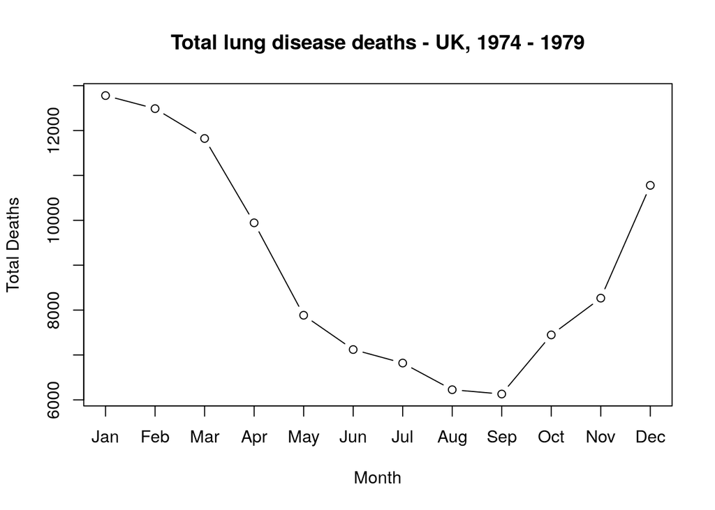

```r
months_deaths <- apply(m_deaths_df, 2,sum)
plot(c(1:12), xaxt = "n", months_deaths, type = 'b', xlab = "Month", ylab = "Total Deaths", main = "Total lung disease deaths - UK, 1974 - 1979")
axis(1, at=1:12, labels=month_names)
```

Generally, we see an increase of lung-disease related deaths during the winter months, and especially in January where it reaches a peak.

##### Problem 3.2

The autoregressive model that we wish to fit for the number of lung-disease related deaths is of the form
$$\begin{align}
\mathbf{Y}_t = \beta_0 + \beta_1 \mathbf{Y}_{t-1} + \beta_{12} Y_{t-12} + \beta_{13}\mathbf{Y}_{t-13} + \epsilon_t.
\end{align}$$

We will proceed to fit this by creating an embedded dataframe from the data in terms of the lagged variables. In particular, we construct the dataframe and we print the final line of dataframe to verify that it matches the final 13 months of the m_deaths_df:

```r
lag_df <- embed(mdeaths, 14)
colnames(lag_df) <- c("y",paste0("lag",1:13))
lag_df <- data.frame(lag_df)
lag_df[length(lag_df$y), ]
```

```
##       y lag1 lag2 lag3 lag4 lag5 lag6 lag7 lag8 lag9 lag10 lag11 lag12
## 59 1341 1294 1081  940  975 1056 1075 1215 1531 1846  1820  2263  1812
##    lag13
## 59  1110
```

```r
m_deaths_df[c(5:6), ]
```

```
##       Jan  Feb  Mar  Apr  May  Jun  Jul  Aug Sep  Oct  Nov  Dec
## 1978 2019 2284 1942 1423 1340 1187 1098 1004 970 1140 1110 1812
## 1979 2263 1820 1846 1531 1215 1075 1056  975 940 1081 1294 1341
```

Indeed, by inspection, we verifty that the lag_df has the appropriate lagged variables.

Then, we form the autoregressive model as before,

```r
m_death_armod <- lm(y ~ lag1 + lag12 + lag13, data.frame(lag_df))
summary(m_death_armod)
```

```
##
## Call:
## lm(formula = y ~ lag1 + lag12 + lag13, data = data.frame(lag_df))
##
## Residuals:
##     Min      1Q  Median      3Q     Max
## -762.71  -81.13  -21.12   61.76  724.06
##
## Coefficients:
##             Estimate Std. Error t value Pr(>|t|)
## (Intercept)  58.1985   120.7358   0.482   0.6317
## lag1          0.2501     0.1327   1.885   0.0647 .
## lag12         0.5356     0.1179   4.542 3.09e-05 ***
## lag13         0.1512     0.1386   1.091   0.2801
## ---
## Signif. codes:  0 '***' 0.001 '**' 0.01 '*' 0.05 '.' 0.1 ' ' 1
##
## Residual standard error: 238.7 on 55 degrees of freedom
## Multiple R-squared:   0.73,  Adjusted R-squared:  0.7153
## F-statistic: 49.56 on 3 and 55 DF,  p-value: 1.19e-15
```

By inspection of the model summary, we notice that only the 12 month behind lagged variable is statistically signifcant at $5\%$.

##### Problem 3.3

We will use the above model to make a prediction for the next month, left out of the current data. In particular, we will make a prediction for January 1980 as

```r
predict(m_death_armod, data.frame(lag1=1341, lag12=2263, lag13=1812),interval="prediction")
```

```
##        fit      lwr      upr
## 1 1879.599 1359.725 2399.474
```

##### Problem 3.4

Using the above prediction of $1879.599$ we will produce a new prediction for February 1980 with the January 1980 prediction as the lag $\mathbf{Y}_{t-1}$ variable. We won’t mind in this case that the number of deaths is non-integer, solely for the prediction purposes. If we were to use the prediction for any sort of inference or explanatory purposes, we would use the prediction interval itself to base conclusions.

```r
predict(m_death_armod, data.frame(lag1=1879.599, lag12=1820, lag13=2263),interval="prediction")
```

```
##        fit     lwr      upr
## 1 1845.247 1345.87 2344.625
```

##### Problem 3.5

To evaluate the fitted values for the autoregressive model, we will first store the values and recall the total number of fitted estimates

```r
m_death_fitted <- m_death_armod$fitted.values
length(m_death_fitted)
```

```
## [1] 59
```

```r
length(mdeaths)
```

```
## [1] 72
```

With 59 fitted values, and recalling that the length of the total dataset is 72, we note that we need to compare the fitted values with the months February 1975 - December 1979. In this case, we will extract a sub-vector of the mdeaths corresponding to these months:

```r
m_deaths_pred_int <- mdeaths[c(14:72)]
length(m_deaths_pred_int)
```

```
## [1] 59
```

We select the 14 date through the end date in the dataset so that the fitted and observed values align; then we plot these together as,

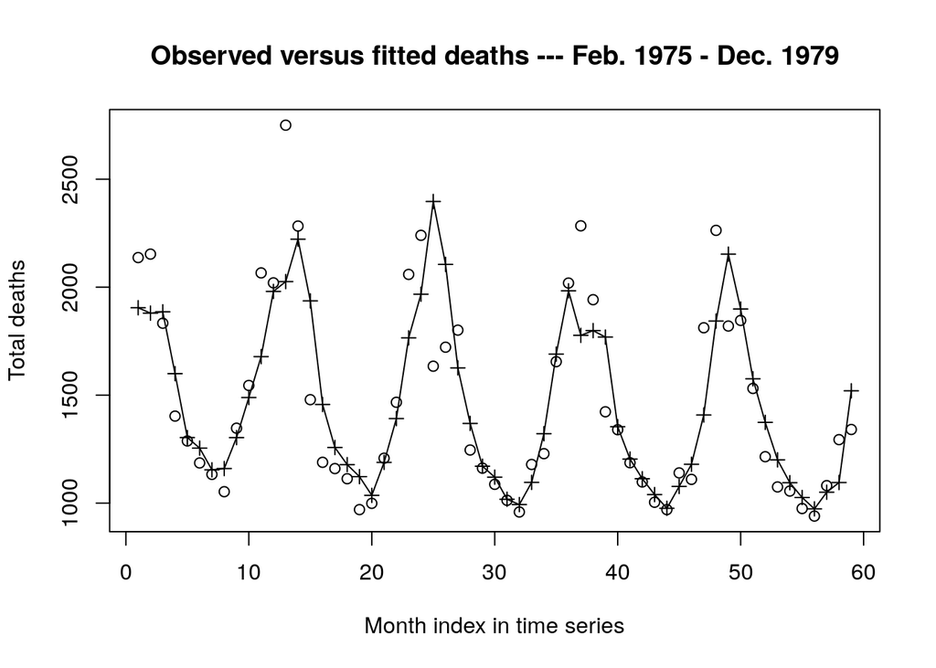

```r
plot(c(1:59),m_deaths_pred_int, xlab = "Month index in time series", ylab = "Total deaths",
main = "Observed versus fitted deaths --- Feb. 1975 - Dec. 1979")
lines(c(1:59),m_death_fitted)
points(c(1:59), m_death_fitted, pch=3)
```

In the above plot, circles are the observed value in each month while the crosses are the fitted values. The trend-line for the auto-regressive model is plotted with the solid line.

From inspection, it appears that the low periods during the summer are better fit by the predictions, while the winter months (with more extreme variance in the observed values) are harder to predict accurately.